# Ford GoBike Data Exploration

## by Jingjun He

## Investigation Overview

In this investigation, I wanted to focus on the following questions: when are most trips taken in terms of time of day, day of week and month of the year. How long does the average trip take? Does the above depend on if a user is a subscriber or customer?

## Dataset Overview

This data set includes information about 2,506,983 individual rides made in a bike-sharing system Ford GoBike covering the greater San Francisco Bay area. The monthly data is provided by Bay Wheels and can be downloaded from their website. For the analysis, I download 12 monthly data from January 2019 to December 2019 to make a full year coverage. The attributes included duration, user type, start/end time, as well as additional information such as bike id, rental access method, start/end station, etc. Thirty-nine abnormal data points were removed from the analysis.

## Distribution of Bike Rides Duration

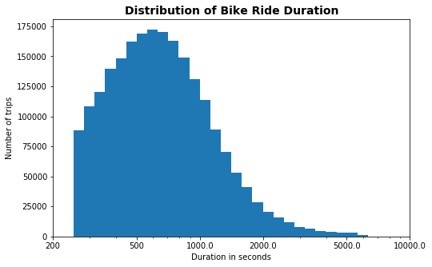

```python
# There's a long-tail in the distribution, filter for duration < 6000 to remove outliers
# and and plot on a log scale instead

duration_filter = df.query('duration_sec < 6000')
log_binsize = 0.05
bins = 10 ** np.arange(2.4, np.log10(duration_filter['duration_sec'].max())+log_binsize, log_binsize)

plt.figure(figsize=[8,5])
plt.hist(data = duration_filter, x = 'duration_sec', bins = bins)
plt.xscale('log')
tick_locs = [200, 500, 1e3, 2e3, 5e3, 1e4] #Set ticks in cycles of 1-3-10 or 1-2-5-10 are very useful for base-10 log transforms.
plt.xticks(tick_locs, tick_locs)
plt.xlabel('Duration in seconds')
plt.ylabel('Number of trips')
plt.title('Distribution of Bike Ride Duration', fontsize=14, fontweight='bold')
plt.show()
```

## Ford GoBike User Types

Majority of the bike users are subscribers(80.6%). Customer is 19.4% for those who do not subscribe.

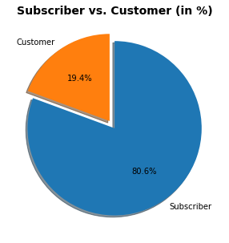

```python
plt.figure(figsize=[7,5])
explode = (0, 0.1)
sorted_counts = df['user_type'].value_counts()
plt.pie(sorted_counts, explode=explode, labels = sorted_counts.index,
        autopct='%1.1f%%',shadow=True, startangle = 90,counterclock = False)
plt.title('Subscriber vs. Customer (in %)', fontsize=14, fontweight='bold');
```

## Average Ride Duration: Subscribers vs. Customers

Although subscribers make a lot more trips than customers, customers generally take longer bike trip than subscribers.

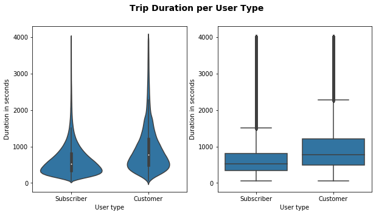

```python
# Set an upper limit of 4000 to remove outliers for the graphs
fig = plt.figure(figsize = [10, 5])
base_color = sns.color_palette()[0]
filter_data = df.query('duration_sec < 4000')

# left plot: violin plot
plt.subplot(1, 2, 1)
ax1 = sns.violinplot(data = filter_data, x = 'user_type', y = 'duration_sec', color = base_color)
plt.xlabel('User type')
plt.ylabel('Duration in seconds')

# right plot: box plot
plt.subplot(1, 2, 2)
sns.boxplot(data = filter_data, x = 'user_type', y = 'duration_sec', color = base_color)
plt.xlabel('User type')
plt.ylabel('Duration in seconds')
plt.ylim(ax1.get_ylim()) # set y-axis limits to be same as left plot
fig.suptitle('Trip Duration per User Type', fontsize=14, fontweight='bold')
plt.show();
```

## Bike Usage in Hour/Day/Month: Subscribers vs. Customers

Different user types does show different usage(in number of rides) patterns.

- Subscribers take most of their trips around 7-9am(peak at 8am) and 4-6pm(peak at 5pm), typical commute hours. They are probably commuters to work/school. Subscribers took more trips during the weekdays and less on weekend.
- The usage trend for customers is relatively constant during the week but with higher usage on Friday and Saturday. Customers show similar pattern with subscribers on a daily basis expect that customers take less monring trips.
- The bike usage of both user types are affected by season. But usage for customers peaks in December, whereas for subscribers it is the opposite. Customers are probably tourist and occasional riders, who take the most rides in December due during the holidays.

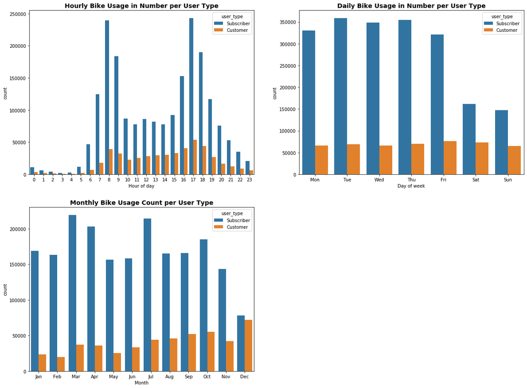

```python
plt.figure(figsize=(20,15))
base_color = sns.color_palette()[0]

# Number of bike rides per hour per user type
plt.subplot(221)
sns.countplot(data = df, x = 'start_hour', hue = 'user_type')
plt.xlabel('Hour of day')
plt.title('Hourly Bike Usage in Number per User Type', fontsize=14, fontweight='bold')

# Number of bike rides per day per user type
plt.subplot(222)
order = ['Mon', 'Tue', 'Wed', 'Thu', 'Fri', 'Sat', 'Sun']
sns.countplot(data = df, x = 'start_dayofweek', hue = 'user_type', order=order)
plt.xlabel('Day of week')
plt.title('Daily Bike Usage in Number per User Type', fontsize=14, fontweight='bold')

# Number of bike rides per month per user type
plt.subplot(223)
sns.countplot(data = df, x = 'start_month', hue = 'user_type')
plt.xlabel('Month')
plt.title('Monthly Bike Usage Count per User Type', fontsize=14, fontweight='bold');
```

## Average Bike Trip Duration in Hour/Day/Month: Subscribers vs. Customers

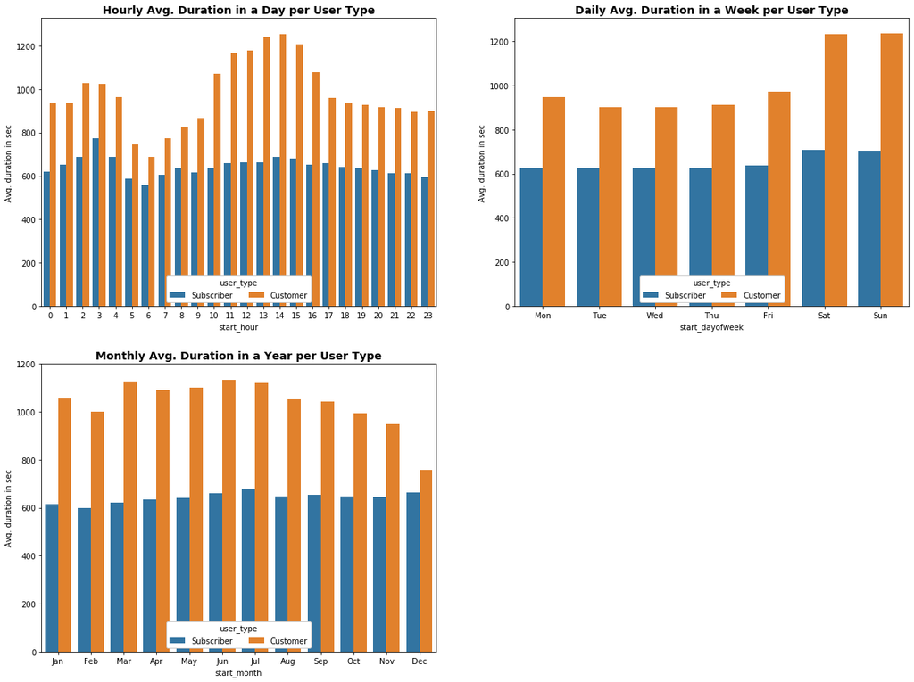

```python
plt.figure(figsize=(20,15))
base_color = sns.color_palette()[0]

# Hourly Avg. Duration in a Day per User Type
plt.subplot(221)
ax = sns.barplot(data = df.query('duration_sec < 6000'), x = 'start_hour', y = 'duration_sec', hue = 'user_type', errwidth = 0)
ax.legend(loc = 8, ncol = 3, framealpha = 1, title = 'user_type')
plt.ylabel('Avg. duration in sec')
plt.title('Hourly Avg. Duration in a Day per User Type', fontsize=14, fontweight='bold')

# Daily Avg. Duration in a Week per User Type
plt.subplot(222)
order = ['Mon', 'Tue', 'Wed', 'Thu', 'Fri', 'Sat', 'Sun']
ax = sns.barplot(data = df.query('duration_sec < 6000'), x = 'start_dayofweek', y = 'duration_sec', hue = 'user_type',
                 errwidth = 0, order=order)
ax.legend(loc = 8, ncol = 3, framealpha = 1, title = 'user_type')
plt.ylabel('Avg. duration in sec')
plt.title('Daily Avg. Duration in a Week per User Type', fontsize=14, fontweight='bold')

# Monthly Avg. Duration in a Year per User Type
plt.subplot(223)
ax = sns.barplot(data = df.query('duration_sec < 6000'), x = 'start_month', y = 'duration_sec', hue = 'user_type', errwidth = 0)
ax.legend(loc = 8, ncol = 3, framealpha = 1, title = 'user_type')
plt.ylabel('Avg. duration in sec')
plt.title('Monthly Avg. Duration in a Year per User Type', fontsize=14, fontweight='bold');
```

## Bike Rides 24x7: Subscribers vs. Customers

The heatmap for different user types strengthened the results we found earlier. But it also reals detailed information. We see large average duration means at 3am Tuesday to Friday and 4-6am Sunday for subscribers. There are some large duraion means occured before 4am Monday to Thursday and some on weekend before 5am.

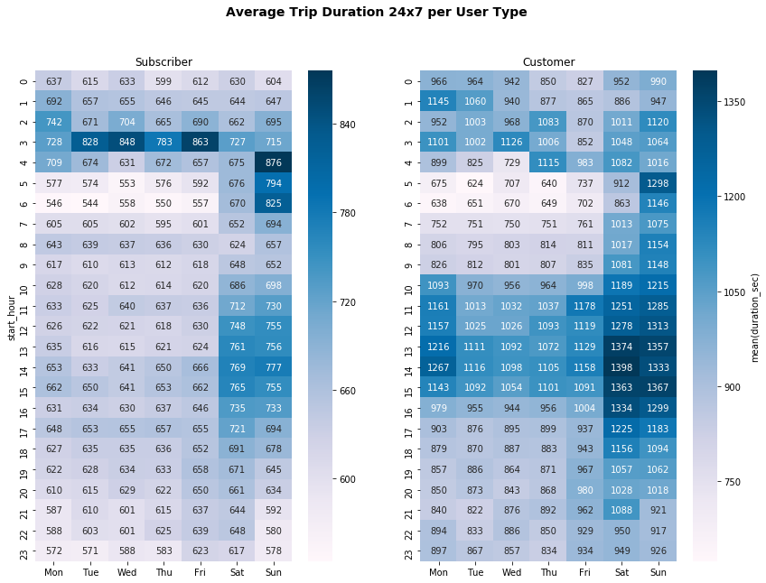

```python
# Average trip duration for 24x7
# Setting the weekday order, https://stackoverflow.com/questions/35193808/re-order-pandas-series-on-weekday
# https://stackoverflow.com/questions/29647749/seaborn-showing-scientific-notation-in-heatmap-for-3-digit-numbers
plt.figure(figsize=(14,10))
df['start_dayofweek'] = pd.Categorical(df['start_dayofweek'],
                                       categories=['Mon','Tue','Wed','Thu','Fri','Sat','Sun'], ordered=True)
filter_data = df.query('duration_sec < 6000')

# left plot: subscriber
plt.subplot(1, 2, 1)
duration_means_s = filter_data.query('user_type == "Subscriber"').groupby(['start_dayofweek',
                                                                           'start_hour']).mean().astype(int)['duration_sec']
duration_means_s = duration_means_s.reset_index(name = 'duration_sec_avg')
duration_means_s = duration_means_s.pivot(index = 'start_hour', columns = 'start_dayofweek',
                                      values = 'duration_sec_avg')
ax1 = sns.heatmap(duration_means_s, cmap ='PuBu', annot=True, fmt='g', annot_kws={"size": 10})
plt.xlabel('')
plt.title('Subscriber')
ax1.set_ylim(23.5 + 0.5, 0.5 - 0.5)  #ax1.get_ylim() -- (23.5, 0.5)
#https://stackoverflow.com/questions/56942670/matplotlib-seaborn-first-and-last-row-cut-in-half-of-heatmap-plot

# right plot: customer
plt.subplot(1, 2, 2)
duration_means_c = filter_data.query('user_type == "Customer"').groupby(['start_dayofweek',
                                                                         'start_hour']).mean().astype(int)['duration_sec']
duration_means_c = duration_means_c.reset_index(name = 'duration_sec_avg')
duration_means_c = duration_means_c.pivot(index = 'start_hour', columns = 'start_dayofweek',
                                      values = 'duration_sec_avg')
ax2 = sns.heatmap(duration_means_c, cmap ='PuBu', annot=True, fmt='g',
            cbar_kws = {'label' : 'mean(duration_sec)'}, annot_kws={"size": 10})
plt.xlabel('')
plt.ylabel('')
plt.title('Customer')
plt.suptitle('Average Trip Duration 24x7 per User Type', fontsize=14, fontweight='bold')
plt.ylim(ax1.get_ylim());    # set y-axis limits to be same as left plot
```

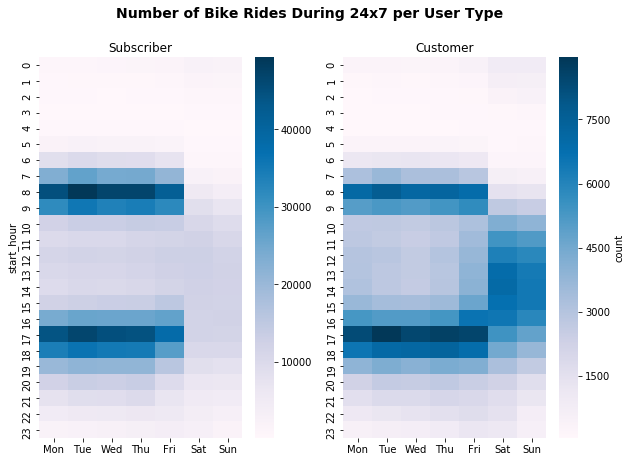

```python
# Number of bike rides taken place during 24x7
plt.figure(figsize=(10,7))
df['start_dayofweek'] = pd.Categorical(df['start_dayofweek'],
                                       categories=['Mon','Tue','Wed','Thu','Fri','Sat','Sun'], ordered=True)
filter_data = df.query('duration_sec < 6000')

# left plot: subscriber
plt.subplot(1, 2, 1)
rides_count_s = filter_data.query('user_type == "Subscriber"').groupby(['start_dayofweek',
                                                                           'start_hour']).size().astype(int)
rides_count_s = rides_count_s.reset_index(name = 'count')
rides_count_s = rides_count_s.pivot(index = 'start_hour', columns = 'start_dayofweek',
                                      values = 'count')
ax1 = sns.heatmap(rides_count_s, cmap ='PuBu')
plt.xlabel('')
plt.title('Subscriber')
ax1.set_ylim(23.5 + 0.5, 0.5 - 0.5)  #ax1.get_ylim() -- (23.5, 0.5)

# right plot: customer
plt.subplot(1, 2, 2)
rides_count_c = filter_data.query('user_type == "Customer"').groupby(['start_dayofweek',
                                                                         'start_hour']).size().astype(int)
rides_count_c = rides_count_c.reset_index(name = 'count')
rides_count_c = rides_count_c.pivot(index = 'start_hour', columns = 'start_dayofweek',
                                      values = 'count')
ax2 = sns.heatmap(rides_count_c, cmap ='PuBu', cbar_kws = {'label' : 'count'})
plt.xlabel('')
plt.ylabel('')
plt.title('Customer')
plt.suptitle('Number of Bike Rides During 24x7 per User Type', fontsize=14, fontweight='bold')
plt.ylim(ax1.get_ylim());    # set y-axis limits to be same as left plot
```